# Tarea_04_2025

- Grafica la red con al menos tres medidas de centralidad.

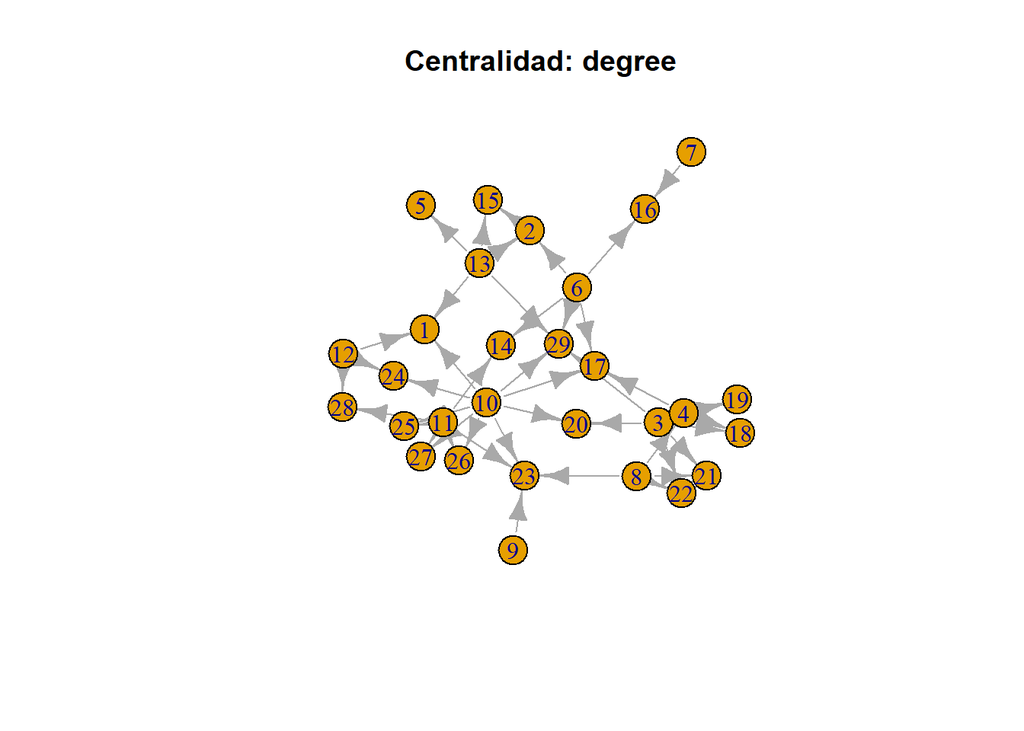

```r
d_mouse <- degree(mouse, mode = "all") #supongo que all
bet_mouse <- betweenness(mouse, directed = TRUE)
close_mouse <- closeness(mouse, mode = "all") #all como en el degree


#plot(d_mouse, main = "Centralidad: degree") corre, pero muestra en puntos la gráfica

#Código: https://www.datacamp.com/tutorial/centrality-network-analysis-R

#Realizar un layout para todos:
layout_mouse <- layout_with_fr(mouse)

# Gráficas
#Degree
plot (mouse, layout = layout_mouse, main = "Centralidad: degree" )
```

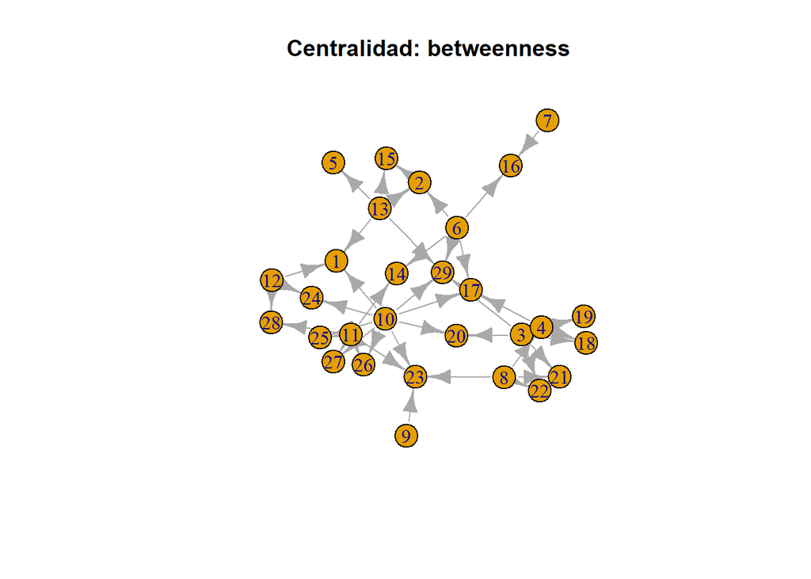

```r
#Betweenness
plot (mouse, layout = layout_mouse,main = "Centralidad: betweenness" )
```

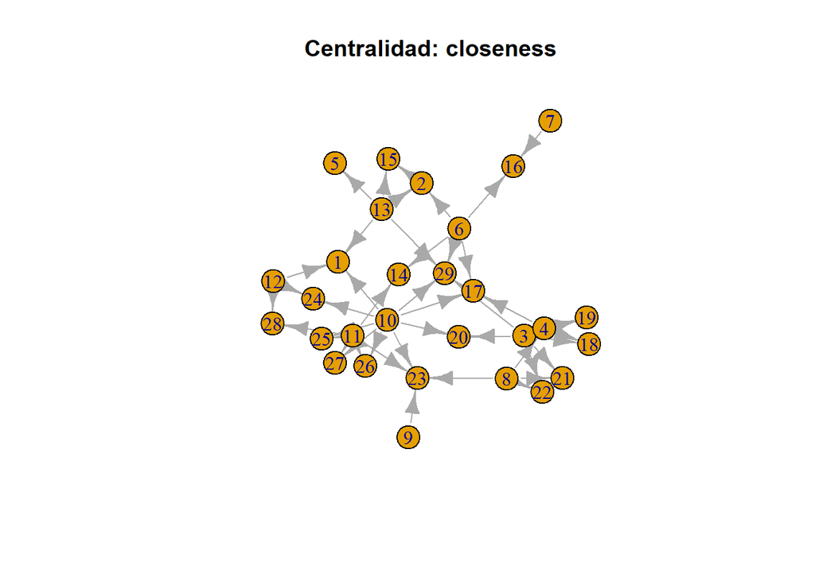

```r
# Closeness Centrality
plot (mouse, layout = layout_mouse, main = "Centralidad: closeness" )
```

- ¿Qué tan densa es la red?

```r
edge_density(mouse)
```

```
## [1] 0.05418719
```

- Clusteriza la red con al menos tres métodos de clusterización. Gráfica la red con esos métodos.

```r
#Código: https://stackoverflow.com/questions/44372499/igraph-split-graph-into-clusters

#Edge-betweeness
get.data.frame(mouse)
```

```
##    from to
## 1     2 15
## 2     3 18
## 3     3 19
## 4     3 20
## 5     3 21
## 6     3 22
## 7     3 29
## 8     4 17
## 9     4 18
## 10    4 19
## 11    6  2
## 12    6 14
## 13    6 16
## 14    6 17
```

[output cut: 30 more lines]

```r
eb_mouse <- edge.betweenness.community(mouse, weights = E(mouse)$value, directed = FALSE, bridges=TRUE)
```

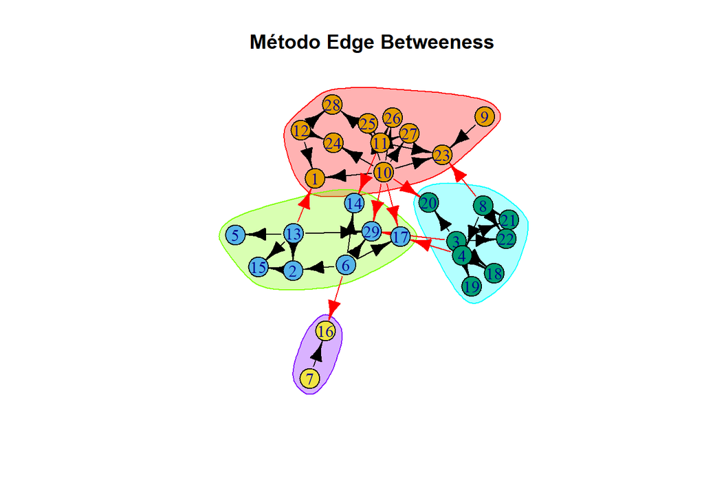

```r
plot(eb_mouse, mouse, main = "Método Edge Betweeness")
```

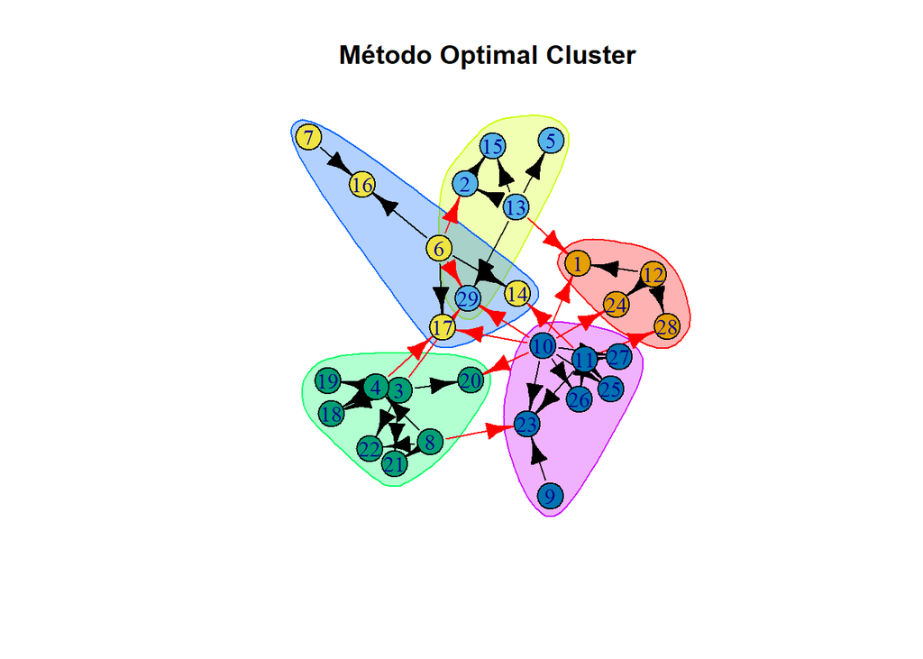

```r
#Optimal Cluster
oc_mouse <- cluster_optimal(mouse, weights = E(mouse)$value)
plot(oc_mouse, mouse, main = "Método Optimal Cluster")
```

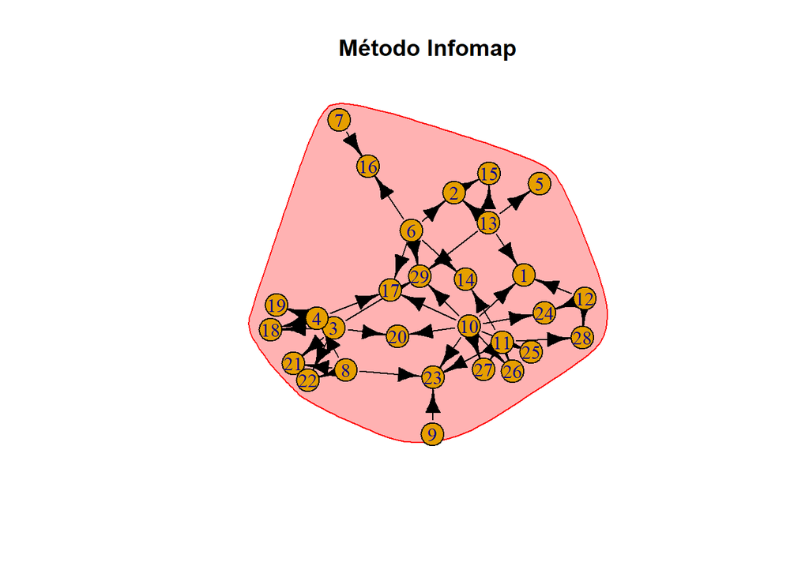

```r
#Infomaps
infomap_mouse <- cluster_infomap(mouse, e.weights = E(mouse)$value)
plot(infomap_mouse, mouse, main = "Método Infomap")
```

El algoritmo Infomap detecta a toda la red mouse en una misma comunidad, probablemente por lo inetrconectada que está la red, mientras que los otros dos métodos si permiten diferenciar distintos clústeres.

5. **Red de coexpresión simulada**

Simula una matriz de expresión con 20 genes en 6 condiciones diferentes.

- Calcula la correlación entre todos los pares de genes.
- Construye una red de coexpresión utilizando un umbral de correlación > 0.8.
- Calcula la distribución de grados.
- Identifica si hay módulos o agrupamientos de genes altamente correlacionados.
- Visualiza la red y discute qué tipo de topología tiene.
6. **Comparación de redes**

Construye dos redes:

- Una red aleatoria tipo Erdos-Rényi.
- Una red tipo “scale-free” usando el modelo Barabási–Albert.

```r
#Erdos-Rényi
g_er <- sample_gnp (100, p = 0.5)
#Scale-free
g_ba <- sample_pa (100 , directed = FALSE)
```

Para ambas redes:

- Compara su grado promedio, distribución de grados, coeficiente de clusterización y diámetro.

```r
comparacion <- function(graf) {
  g_prom <- mean (degree (graf, mode = "total"))
  g_dist <- degree_distribution(graf)
  cc <- transitivity(graf, type = "average") #supongo que en este caso el promedio e smejor que el local
  diam <- diameter(graf)

  cat("Grado promedio:", g_prom, "\n")
  cat("Distribución de grados:", g_dist, "\n")
  cat("CC promedio:", cc, "\n")
  cat("Diámetro:", diam, "\n")
}

comparacion(g_er)
```

```
## Grado promedio: 50.1
## Distribución de grados: 0 0 0 0 0 0 0 0 0 0 0 0 0 0 0 0 0 0 0 0 0 0 0 0 0 0 0 0 0 0 0 0 0 0 0 0.01 0 0 0 0.01 0 0.01 0 0.02 0.06 0.09 0.05 0.11 0.03 0.06 0.08 0.1 0.08 0.05 0.02 0.05 0.03 0.06 0.03 0.04 0 0.01
## CC promedio: 0.5069783
## Diámetro: 2
```

```r
comparacion(g_ba)
```

```
## Grado promedio: 1.98
## Distribución de grados: 0 0.61 0.2 0.1 0.02 0.03 0.01 0 0.01 0 0.01 0 0 0 0 0 0 0 0 0 0.01
## CC promedio: 0
## Diámetro: 12
```

- Interpreta las diferencias en el contexto de redes biológicas.

Debido a que las uniones entre nodos vecinos son tan escasas entre sí en la red Scale-free, el coeficiente de clústering promedio resulta ser 0, por lo que no podríamos esperar grupos estrechamente unidos entre sí, lo que también es conformado por diámetro, que denota una trayectoria larga entre nodos. Por otro lado, el valor del coeficiente de clústering para Erdos-Rényi indican que hay un cierto nivel de clústering, por lo que podríamos esperar ver algunos grupos de nodos, puesto que los nodos vecinos tienen una mayor probabilidad de conectarse entre sí, por lo que podemos ver un número de diámatro pequeño (2).

Esto nos deja ver que las redes scale-free se aproximan más a las redes que vemos en la realidad, donde se refleja mejor la presencia de hubs, que a su vez brindan robustez al modelo, que es lo que esperaríamos ver en procesos biológicos como las interacciones entre proteínas o vías metabólicas, las cuales sabemos son bastante complejas.